# Group Assignment 2

Analytics for Strategy

Wahib Charamand, Valentin de la Pena, Jinwen Wu, Abe Rubin

2024-02-02

```r
# Packages
library(dplyr)
library(haven)
library(broom)
library(lfe)
library(sandwich)
library(lmtest)
```

```r
# Load Dataset
data <- read.csv("united-1.csv")
```

```r
# Summarize Data
summary(data)
```

```
##     bookid              flight    departuredate          month        day
##  Length:3491        Min.   :360   Length:3491        Min.   :5   Min.   : 1.0
##  Class :character   1st Qu.:360   Class :character   1st Qu.:5   1st Qu.: 8.0
##  Mode  :character   Median :360   Mode  :character   Median :5   Median :15.0
##                     Mean   :360                      Mean   :5   Mean   :14.5
##                     3rd Qu.:360                      3rd Qu.:5   3rd Qu.:21.0
##                     Max.   :360                      Max.   :5   Max.   :28.0
##       year      destination           origin              noshow
##  Min.   :2007   Length:3491        Length:3491        Min.   :0.00
##  1st Qu.:2007   Class :character   Class :character   1st Qu.:0.00
##  Median :2007   Mode  :character   Mode  :character   Median :0.00
##  Mean   :2007                                         Mean   :0.11
##  3rd Qu.:2007                                         3rd Qu.:0.00
##  Max.   :2007                                         Max.   :1.00
##    daystodep      mileageplus        assignedseat       numberinparty
##  Min.   :  5.00   Length:3491        Length:3491        Min.   : 1.000
##  1st Qu.: 16.00   Class :character   Class :character   1st Qu.: 1.000
##  Median : 29.00   Mode  :character   Mode  :character   Median : 1.000
##  Mean   : 42.18                                         Mean   : 1.425
##  3rd Qu.: 55.00                                         3rd Qu.: 2.000
##  Max.   :371.00                                         Max.   :20.000
##    eticketed      bookingcountry         upline          downline
##  Min.   :0.0000   Length:3491        Min.   :0.0000   Min.   :0.0000
##  1st Qu.:1.0000   Class :character   1st Qu.:0.0000   1st Qu.:0.0000
##  Median :1.0000   Mode  :character   Median :0.0000   Median :0.0000
##  Mean   :0.8857                      Mean   :0.3807   Mean   :0.2498
##  3rd Qu.:1.0000                      3rd Qu.:1.0000   3rd Qu.:0.0000
##  Max.   :1.0000                      Max.   :1.0000   Max.   :1.0000
##   modifycount      bookingclass            dow             rand
##  Min.   : 0.0000   Length:3491        Min.   :0.000   Min.   :0.0003367
##  1st Qu.: 0.0000   Class :character   1st Qu.:1.000   1st Qu.:0.2441542
##  Median : 1.0000   Mode  :character   Median :3.000   Median :0.4966833
##  Mean   : 0.7794                      Mean   :3.093   Mean   :0.4975136
##  3rd Qu.: 1.0000                      3rd Qu.:5.000   3rd Qu.:0.7449231
##  Max.   :11.0000                      Max.   :6.000   Max.   :0.9988082
```

```r
# Recode Date of Departure Variable
data$departuredate <- as.Date(data$departuredate, format="%d-%b-%y")

# Filter Data to Before Memorial Day Weekend (Before May 25, 2007)
filtered_data <- subset(data, departuredate <= as.Date("2007-05-25"))

# Summarize Filtered Data
summary(filtered_data)
```

```
##     bookid              flight    departuredate            month
##  Length:3186        Min.   :360   Min.   :2007-05-01   Min.   :5
##  Class :character   1st Qu.:360   1st Qu.:2007-05-07   1st Qu.:5
##  Mode  :character   Median :360   Median :2007-05-14   Median :5
##                     Mean   :360   Mean   :2007-05-13   Mean   :5
##                     3rd Qu.:360   3rd Qu.:2007-05-19   3rd Qu.:5
##                     Max.   :360   Max.   :2007-05-25   Max.   :5
##       day             year      destination           origin
##  Min.   : 1.00   Min.   :2007   Length:3186        Length:3186
##  1st Qu.: 7.00   1st Qu.:2007   Class :character   Class :character
##  Median :14.00   Median :2007   Mode  :character   Mode  :character
##  Mean   :13.29   Mean   :2007
##  3rd Qu.:19.00   3rd Qu.:2007
##  Max.   :25.00   Max.   :2007
##      noshow         daystodep      mileageplus        assignedseat
##  Min.   :0.0000   Min.   :  5.00   Length:3186        Length:3186
##  1st Qu.:0.0000   1st Qu.: 16.00   Class :character   Class :character
##  Median :0.0000   Median : 29.00   Mode  :character   Mode  :character
##  Mean   :0.1111   Mean   : 41.51
##  3rd Qu.:0.0000   3rd Qu.: 53.00
##  Max.   :1.0000   Max.   :371.00
##  numberinparty      eticketed      bookingcountry         upline
##  Min.   : 1.000   Min.   :0.0000   Length:3186        Min.   :0.0000
##  1st Qu.: 1.000   1st Qu.:1.0000   Class :character   1st Qu.:0.0000
##  Median : 1.000   Median :1.0000   Mode  :character   Median :0.0000
##  Mean   : 1.393   Mean   :0.8861                      Mean   :0.3807
##  3rd Qu.: 2.000   3rd Qu.:1.0000                      3rd Qu.:1.0000
##  Max.   :20.000   Max.   :1.0000                      Max.   :1.0000
##     downline       modifycount     bookingclass            dow
##  Min.   :0.0000   Min.   :0.0000   Length:3186        Min.   :0.00
##  1st Qu.:0.0000   1st Qu.:0.0000   Class :character   1st Qu.:2.00
##  Median :0.0000   Median :1.0000   Mode  :character   Median :3.00
##  Mean   :0.2505   Mean   :0.7684                      Mean   :3.15
##  3rd Qu.:1.0000   3rd Qu.:1.0000                      3rd Qu.:5.00
##  Max.   :1.0000   Max.   :8.0000                      Max.   :6.00
##       rand
##  Min.   :0.0003367
##  1st Qu.:0.2449565
##  Median :0.4947979
##  Mean   :0.4971074
##  3rd Qu.:0.7438124
##  Max.   :0.9988082
```

```r
# Create Relevant Dummy Variables for Filtered Data
  # Assigned Seat
filtered_data$assignedseat <- as.integer(filtered_data$assignedseat == "Y")
  # Booking Country (US or Not)
filtered_data$bookingcountry <- as.integer(filtered_data$bookingcountry == "US")

# Create Relevant Dummy Variables for Unfiltered Data
  # Assigned Seat
data$assignedseat <- as.integer(data$assignedseat == "Y")
  # Booking Country (US or Not)
data$bookingcountry <- as.integer(data$bookingcountry == "US")
```

```r
# Create Logit Model
model <- glm(noshow ~
               numberinparty +  # Size of Party
               daystodep + # Days Between Booking/Modification and Departure
               eticketed + # Whether Booking Was an E-Ticket
               assignedseat + # Wheter a Seat Was Assigned
               bookingcountry + # Whether Booking Was Made in US
               downline + # If Booking Had Downline Connection
               upline,  # If Booking Had Upline Connection
             data = filtered_data,
             family = binomial(link = "logit"))

# Summarize Logit Model
coeftest(model, vcovCL, type='HC1')
```

```
##
## z test of coefficients:
##
##                   Estimate  Std. Error z value  Pr(>|z|)
## (Intercept)    -1.17790157  0.25706877 -4.5820 4.604e-06 ***
## numberinparty   0.04258991  0.05907627  0.7209    0.4710
## daystodep       0.00049115  0.00181476  0.2706    0.7867
## eticketed      -1.24182605  0.18577864 -6.6844 2.318e-11 ***
## assignedseat   -0.72069392  0.12300723 -5.8590 4.658e-09 ***
## bookingcountry  0.21091442  0.17199740  1.2263    0.2201
## downline       -0.17585087  0.17050283 -1.0314    0.3024
## upline          0.90617180  0.11622942  7.7964 6.370e-15 ***
## ---
## Signif. codes:  0 '***' 0.001 '**' 0.01 '*' 0.05 '.' 0.1 ' ' 1
```

Question 1:

1. The intercept represents the log odds of the dependent variable being 1 (a no-show) when all the independent variables in the model are held at zero. Given the intercept value of -1.17790157, the odds of a no-show are e^(-1.17790157), approximately 0.3080. From the formula [Probability = Odds/(1+Odds)], the probability of a no-show is approximately 23.54%. So, under the hypothetical baseline conditions set by the model (non-electronic ticket, no assigned seat, booking not made in the US, no downline or upline connections, no members of the party, and booking made on the day of departure), the implied probability of a passenger being a no-show is about 23.54%. This is, of course, an unrealistic situation, as there would never be 0 members of a party.

Question 2:

1. The effect of adding an upline connection on no-show rates is statistically significant, with a p-value 6.370e-15 and a positive coefficient of about 0.90617180. This indicates that there is a significant association between having an upline connection and the likelihood of being a no-show. However, the effect of adding a downline connection is not statistically significant, with a p-value of 0.3024. This means that, based on the available data, we cannot confidently assert that having a downline connection significantly affects the likelihood of being a no-show.
2. The coefficient for an upline connection is 0.90617180, which means that for each additional upline connection, the odds of being a no-show are multiplied by e^(0.90617180) = 2.47483023067.
3. For a baseline probability, consider an individual who is traveling alone, books a flight 7 days before departure from within the U.S., and chooses an e-ticket with an assigned seat and no connections. This archetype is prevalent within the business and finance industry, representing a considerable segment of air travel demand. By adopting this model as our baseline, we afford ourselves a robust platform from which to explore and quantify the impacts of varying travel parameters, such as the addition of connections.

```r
# Create Hypothetical Traveler Without Upline
typical_business_traveler <- list(
  numberinparty = 1,
  daystodep = 7,
  bookingcountry = 1,
  eticketed = 1,
  assignedseat = 1,
  upline = 0,
  downline = 0
)

# Predict Probability of No-Show for Hypothetical Traveler Without Upline
predicted_business_traveler <- predict(model,
                                           newdata = typical_business_traveler,
                                           type = "response")

# Create Hypothetical Traveler With Upline
typical_business_traveler_with_upline <- list(
  numberinparty = 1,
  daystodep = 7,
  bookingcountry = 1,
  eticketed = 1,
  assignedseat = 1,
  upline = 1,
  downline = 0
)

# Predict Probability of No-Show for Hypothetical Traveler With Upline
predicted_business_traveler_with_upline <- predict(model,
                                           newdata = typical_business_traveler_with_upline,
                                           type = "response")

# Print Probabilities
print(predicted_business_traveler)
```

```
##          1
## 0.05297631
```

```r
print(predicted_business_traveler_with_upline)
```

```
##         1
## 0.1216062
```

Based on our model output, for a typical business traveler without an upline connection, the predicted probability of being a no-show is approximately 5.30%. In contrast, for an identical traveler with an upline connection, the predicted probability increases to approximately 12.16%.

```r
# Filter Data to Memorial Day Weekend
memorial_weekend_data <- subset(data, departuredate >= as.Date("2007-05-26") & departuredate <= as.Date("2007-05-28"))

# Calculate No Shows Probability
probability_noshows_memorial_day <- predict(model, memorial_weekend_data, type = "response")
memorial_weekend_data$predicted_noshows_prob <- probability_noshows_memorial_day

# Calculate Predicted No Shows for Party
memorial_weekend_data$predicted_noshows_memorial_day <- memorial_weekend_data$numberinparty*memorial_weekend_data$predicted_noshows_prob

# Calculate Actual No Shows for a Party (Total)
memorial_weekend_data$actual_noshows <- memorial_weekend_data$numberinparty*memorial_weekend_data$noshow

# Examine Predicted No-Shows vs. Realized
cat("Actual No-Shows",
    sum(memorial_weekend_data$actual_noshows), "\n")
```

```
## Actual No-Shows 45
```

```r
cat("Predicted No-Shows",
    sum(memorial_weekend_data$predicted_noshows_memorial_day), "\n")
```

```
## Predicted No-Shows 64.58884
```

Question 3:

1. Based on our model, we expect 64.5884 absences during the memorial_weekend. There are actually 45 actual absences as recorded in the data. Therefore, wee overestimated the number of absences over Memorial Day Weekend. This would not be good for United, as, overestimating the number of no-shows could result in more passengers showing up than are seats available on flights.

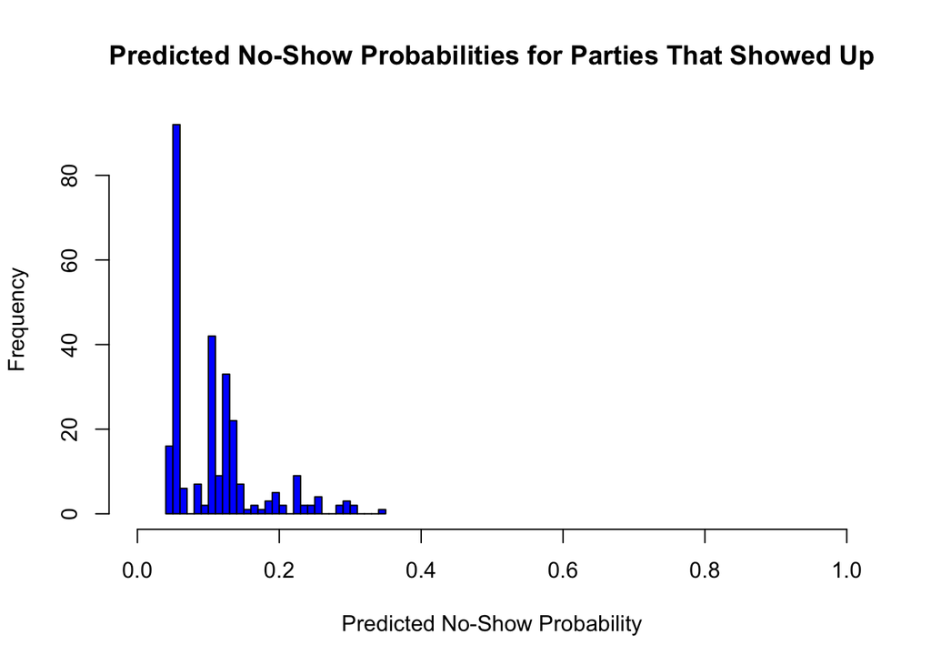

```r
# Histogram for parties that did show up
hist(memorial_weekend_data$predicted_noshows_prob[memorial_weekend_data$noshow == 0],
     breaks = 30, col = 'blue',
     main = 'Predicted No-Show Probabilities for Parties That Showed Up',
     xlab = 'Predicted No-Show Probability', xlim = c(0, 1))
```

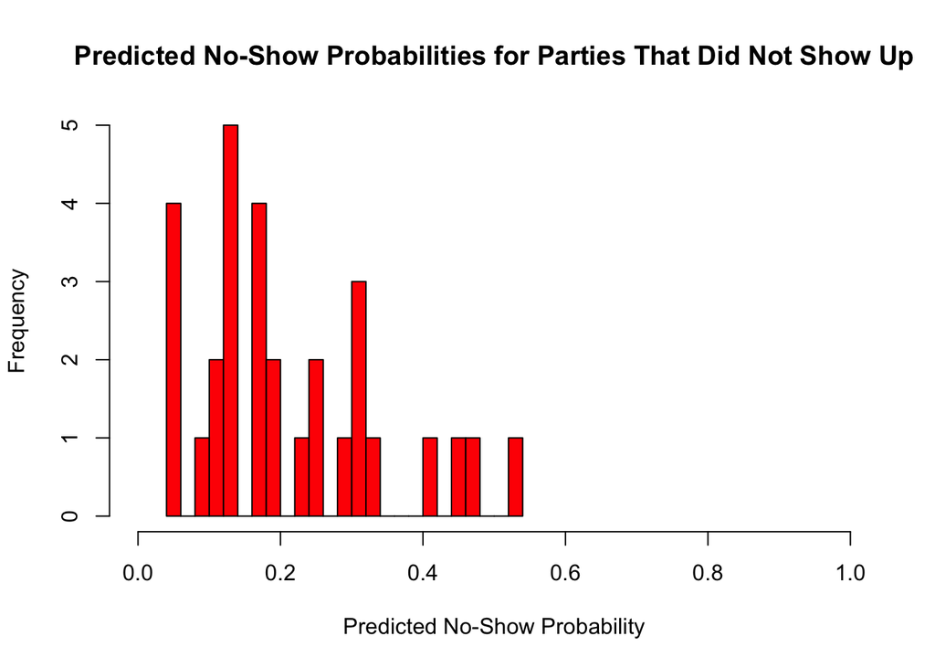

```r
# Histogram for parties that did not show up
hist(memorial_weekend_data$predicted_noshows_prob[memorial_weekend_data$noshow == 1],
     breaks = 30, col = 'red',
     main = 'Predicted No-Show Probabilities for Parties That Did Not Show Up',
     xlab = 'Predicted No-Show Probability', xlim = c(0, 1))
```

3. From our answers in parts (a) and (b), we can see that our predictions are considerably flawed. In part (a), we found that our model overestimated the number of no-shows Memorial Day Weekend by approximately 19.5 passengers, more than 33% overestimated This could be particularly detrimental for United’s decision-making, as, using this model, United may overbook flights under the expectation that passengers will no-show, and instead have too many passengers show up, causing upset customers and other issues. Our answer in part (b) further demonstrated flaws in our model. Our histograms for predicted no-show probabilities among parties that did and didn’t show up weren’t considerably different. While we saw slightly hire probabilities of a no-show among parties that did, in fact, no show, there were also considerable low probabilities in line with those seen among parties that did show up. Therefore, our model was not the best predictor of this behavior.